# Milestone Report

Lawrence Lau

July 22, 2015

This is the Milestone Report (I almost named it Millstone Report) of the Capstone Project for Johns Hopkins’s Data Scientist Certificate Program through Coursera. The task for the Capstone Project is to create an algorithm that predicts/suggests the next word of an user input phrase.

## Data Acquisition

The first step of the process was to download the [database of documents](http://d396qusza40orc.cloudfront.net/dsscapstone/dataset/Coursera-SwiftKey.zip) from a corpus called [HC Corpora](http://www.corpora.heliohost.org) which we’ll use to train our algorithm to predict the next word.

Next, the English documents containing Twitter, Blog, and News entries are read into R.

```r
#english blogs
enBlogs <- readLines("~/datasciencecoursera/Courses/Capstone/Coursera-SwiftKey/final/en_US/en_US.blogs.txt")

#english twitter
enTwitter <- readLines("~/datasciencecoursera/Courses/Capstone/Coursera-SwiftKey/final/en_US/en_US.twitter.txt")

#english news
enNews <- readLines("~/datasciencecoursera/Courses/Capstone/Coursera-SwiftKey/final/en_US/en_US.news.txt")
```

## Basic Summary Statistics and Exploratory Analysis

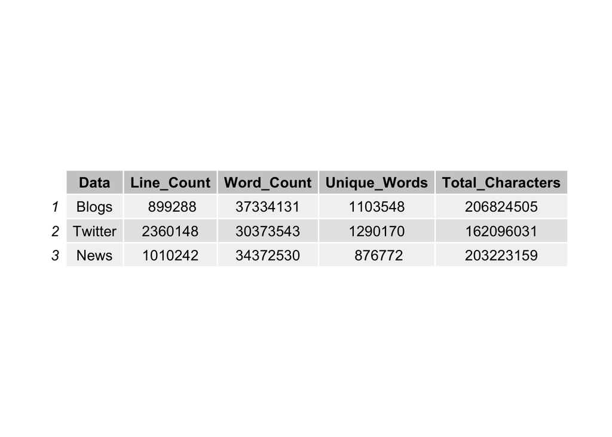

## Process Familiarization and Exploratory Analysis with 1% Subset

At this point I’d just been reading in the text files and doing basic word and line counts. But even then it’d been taking a long time on my computer to do that. So for further analysis I subsetted each of the documents to 1% of their original size and combined it into one larger subset, enSubset.

```r
library(quanteda)
enBlogsSubset <- sample(enBlogs, size=enBlogsLines*.01, replace=FALSE) #8992 lines
enTwitterSubset <- sample(enTwitter, size=enTwitterLines*.01, replace=FALSE) #23601 lines
enNewsSubset <- sample(enNews, size=enNewsLines*.01, replace=FALSE) #10102 lines
enSubset <- c(enBlogsSubset, enTwitterSubset, enNewsSubset) #for dfm
```

Then I used the dfm() function from the Quanteda package to stem, remove stop words, lowercase, and tokenize enSubset.

```r
en.analyze.dfm <- dfm(enSubset, ignoredFeatures = stopwords("english"), stem = TRUE)
```

```
##
##    ... lowercasing
##    ... tokenizing
##    ... indexing 42,695 documents
##    ... shaping tokens into data.table, found 1,002,288 total tokens
##    ... stemming the tokens (english)
##    ... ignoring 174 feature types, discarding 433,985 total features (43.3%)
##    ... summing tokens by document
##    ... indexing 37,206 feature types
##    ... building sparse matrix
##    ... created a 42695 x 37206 sparse dfm
##    ... complete. Elapsed time: 3.77 seconds.
```

Quanteda’s dfm() function is much faster than the process which uses the tm_map() function to clean the corpus which you then have to turn into a DocumentTermMatrix. Quanteda instead produces a Document-Feature Matrix which I used to explore the subset.

Here’s a histogram of the 25 most frequent words (after stepping and without stop words)

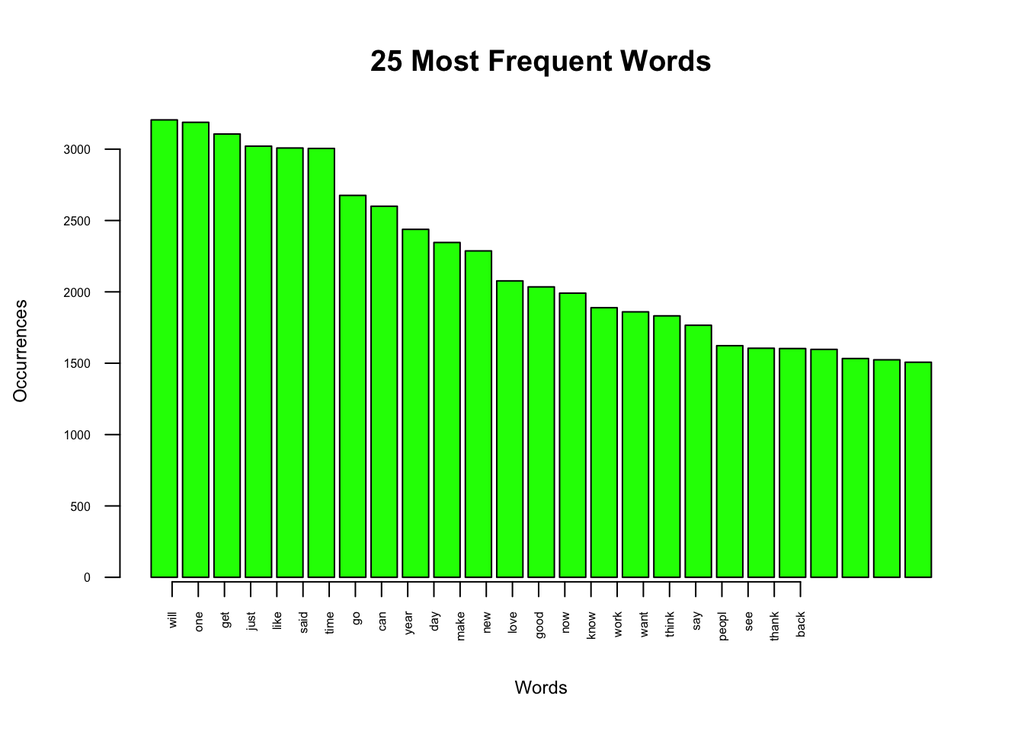

Wordcloud() from package wordcloud is a program that creates an easily discernible visual representation of the most frequently used words.

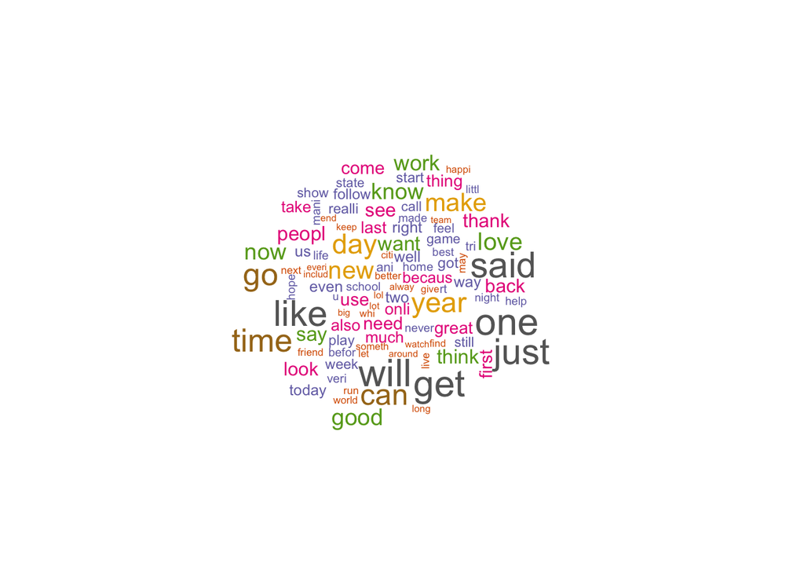

```r
#word cloud after stemming sans stop words
library(wordcloud)
top100words.analyze <- as.data.frame(head(freq.analyze, 100))
wordcloud(rownames(top100words.analyze), top100words.analyze[,1], scale=c(2,.1),
          colors=brewer.pal(8, "Dark2"))
```

## ngrams

Dfm() has an argument “ngrams” which allows the user to set what type of ngrams it wants returned, in this case this is an unigram so I put 1. Notice that stopwords are also being removed and words are being stemmed. What’s returned is a document-feature matrix which I pass to colSums to sum the number of occurrences of each unique unigram, also known as the frequencies of each unigram. After sorting the frequencies from most frequent to least frequent I prune out any unigrams that don’t occur at least 10 times. Rinse and repeat for all ngrams.

```r
en.analyze.dfm.unigrams <- dfm(enSubset, ignoredFeatures = stopwords("english"), stem = TRUE, ngrams = 1, verbose = FALSE)
en.analyze.dfm.uni.freq <- colSums(en.analyze.dfm.unigrams)
uni.freq <- sort(en.analyze.dfm.uni.freq, decreasing=TRUE)
uni.freq.prune <- as.numeric()
for (i in 1:length(uni.freq)) {
    if (uni.freq[i] > 10) {
        uni.freq.prune <- c(uni.freq.prune, uni.freq[i]) }
}
```

A histogram of the top 25 unigrams.

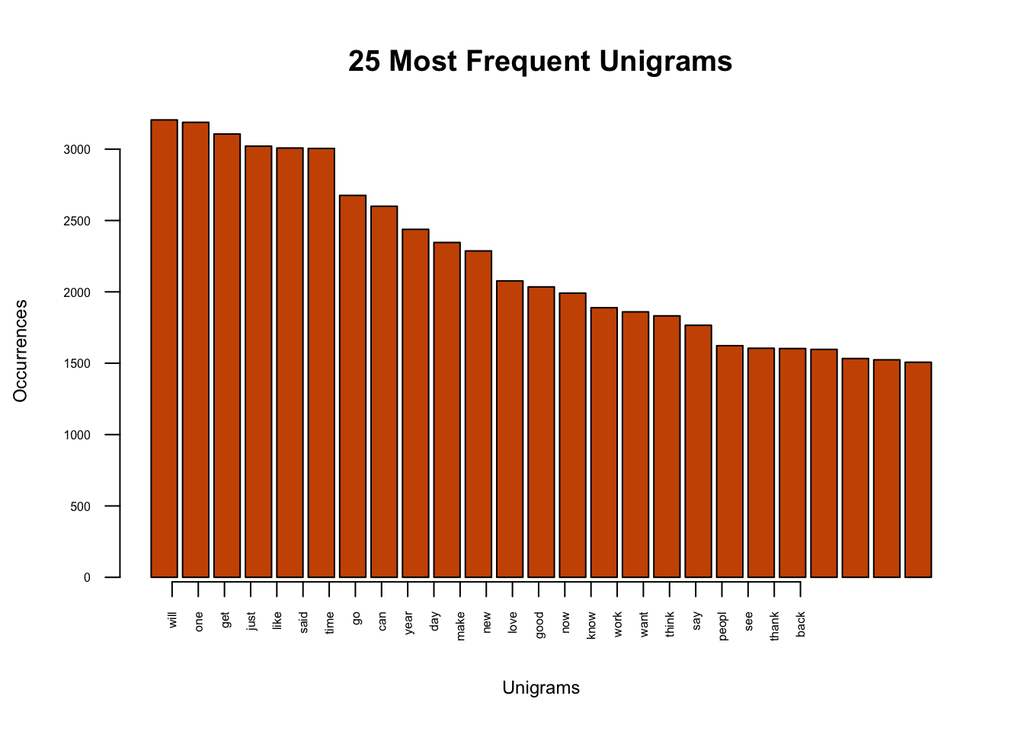

Top 25 bigrams.

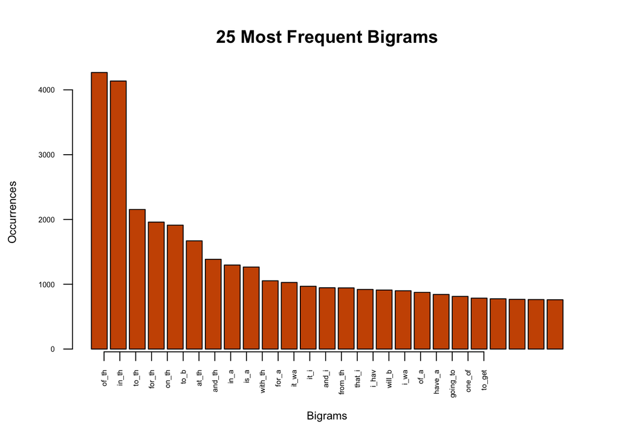

Top 25 trigrams.

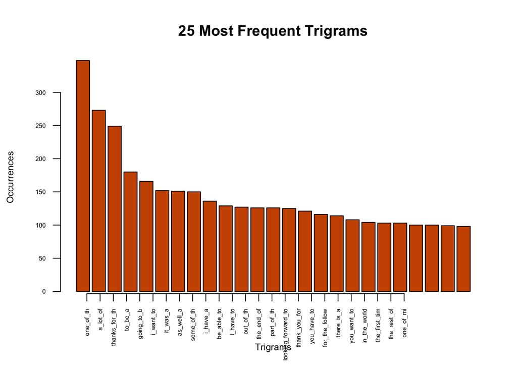

So far so good. But look what happens starting in the quadgrams and continuing onward…

Top 25 Quadgrams.

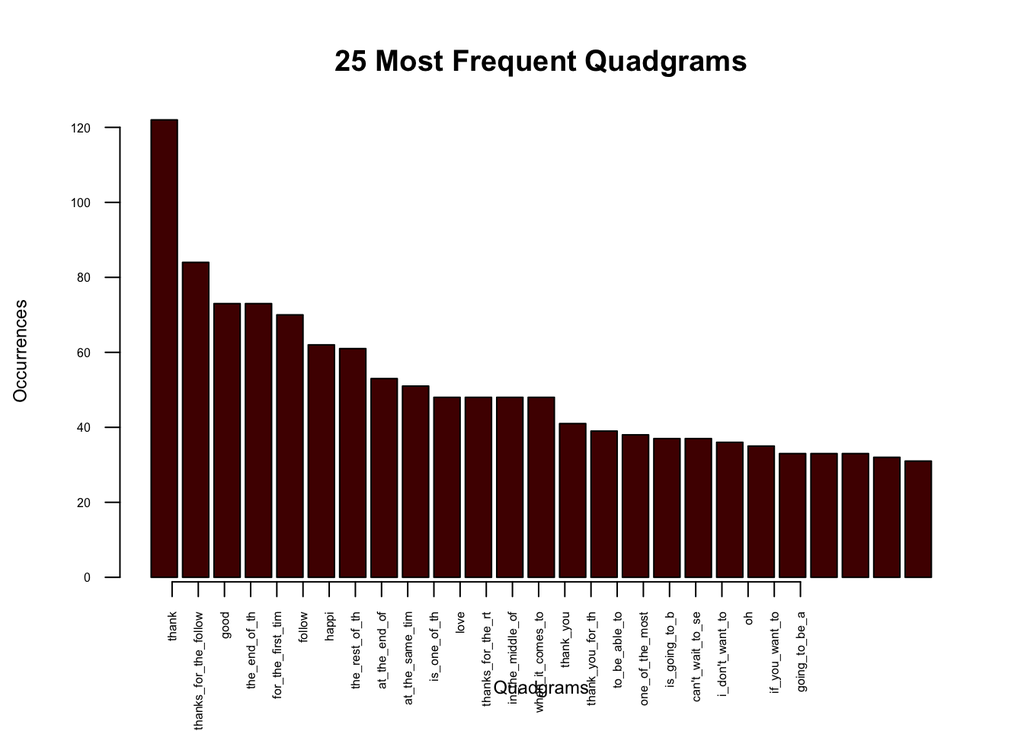

Top 25 Pentagrams.

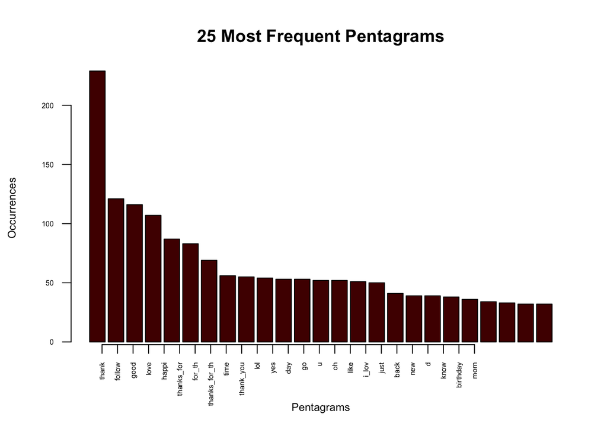

Top 25 Hexagrams.

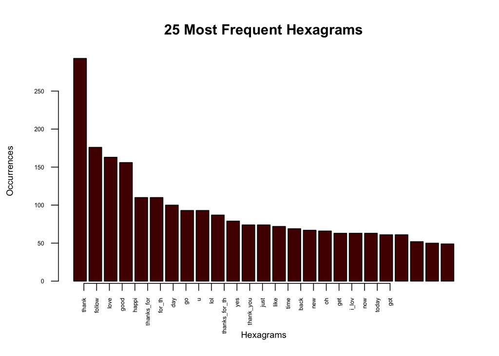

## Further Plans

After I smooth out the ngram creation process I’m going to go back and create ngrams (all the way to decagrams) and store them as an indexed data.frame that is searchable in order to predict the next word based on probability. The prediction of the next word, given a phrase, will be determined by an algorithm that’s trained by the indexed data.frame. Should a word appear in the given phrase that isn’t in the index I’ll need to see if I can add a thesaurus or dictionary function that will be a susbstitute for that word. Also I need to figure out how to weed out misspelled words. After that, I’ll produce a Shiny App that will provide a front end for a user to interface with the algorithm. If you have any feedback please please please share. Thanks!